# How effectively can diet predict Plasma Glucose in the HHANES Hispanic population sample of 1982-1984?

## 0.1 Preliminaries

```r
library(Hmisc)
library(car)
library(haven)
library(ggplot2)
library(tableone)
library(arm)
library(leaps)
library(pander)
library(ROCR)
library(skimr)
library(rms)
library(broom)
library(tidyverse)
```

# 1 Task 1: Data Source

I selected a 994 subjects sample of the **Hispanic Health and Nutrition Examination Survey“** [HHANES](https://www.cdc.gov/nchs/nhanes/hhanes.htm) conducted by the National Center for Health Statistics (NCHS) from 1982 to 1984. This data is interesting because it was collected on”the three largest Hispanic subgroups“, Mexican-americans, Cuban-americans, and Puerto Ricans.

The data is accessible to the public, and it is provided in several files that need to be merged. I selected to use the sections: “Diabetes and OGTT Data, Ages 20-74 years, 6506” and “Dietary Practices, Food Frequency and Total Nutrient Intake, 6525”. In addition the National Center for Health Statistics provids with SAS code to appropriately inport the data which is in .txt format. Thus, I first imported the data using the SAS files provided by NCHS, and exported a SAS file. Secondly, I imported the SAS files into R using the “haven” package, and continued to merge and create a CSV file.

# 2 Task 2: Load and Tidy the Data

## 2.1 Importing SAS files

```r
NHANES_Hisp_DM <- read_sas("d_6506.sas7bdat")
```

```r
NHANES_Hisp_DP <- read_sas("d_6525.sas7bdat")
```

### 2.1.1 Selecting variables of interest

```r
NHANE_Hisp_DM1 <- NHANES_Hisp_DM %>%
  select("SEQN", "HHDM0030", "HHDM0046", "HHDM0047","HHDM0048", "HHDM0054", "HHDM0056", "HHDM0057", "HHDM0059", "HHDM0074", "HHDM0089", "HHDM0137", "HHDM0139", "HHDM0165", "HHDI0517","HHDI0405")
```

```r
NHANE_Hisp_DP1 <- NHANES_Hisp_DP %>%
  filter(complete.cases(SEQN,HHDB0643, HHDB0628, HHDB0610, HHDB0598, HHDB0595, HHDB0592, HHDB0574, HHDB0565)) %>%
  select("SEQN","HHDB0643", "HHDB0628", "HHDB0610", "HHDB0598", "HHDB0595", "HHDB0592", "HHDB0574", "HHDB0565")
```

## 2.2 Merging Files by SEQN

```r
NHANES_Hisp <- merge(NHANE_Hisp_DM1, NHANE_Hisp_DP1, by = "SEQN")%>% tbl_df
```

## 2.3 Renaming: Better names for variables

```r
HHANES_Hisp <- rename(NHANES_Hisp, age = HHDM0030, sex=HHDM0046, race=HHDM0047, national.origin = HHDM0048,edu= HHDM0054, edu1=HHDM0056, marital.status= HHDM0057, occupation= HHDM0059, insurance=HHDM0074, medicaid= HHDM0089, incomegroup=HHDM0137, percapita.i = HHDM0139, number.inhabitants = HHDM0165, plasma.glucose=HHDI0517, fruit=HHDB0565,vegetables= HHDB0574, sugar=HHDB0592, sodas=HHDB0595, liquor= HHDB0610, art.sweetener= HHDB0643,water= HHDB0628, cake.cookies=HHDB0598, DM_self_reported=HHDI0405 )
```

```r
names(HHANES_Hisp)
```

```
 [1] "SEQN"               "age"                "sex"
 [4] "race"               "national.origin"    "edu"
 [7] "edu1"               "marital.status"     "occupation"
[10] "insurance"          "medicaid"           "incomegroup"
[13] "percapita.i"        "number.inhabitants" "plasma.glucose"
[16] "DM_self_reported"   "art.sweetener"      "water"
[19] "liquor"             "cake.cookies"       "sodas"
[22] "sugar"              "vegetables"         "fruit"
```

## 2.4 Data Management

### 2.4.1 Recoding Variable ‘plasma.glucose’

Recoding the value 888 to Missing =NA

```r
HHANES_Hisp$plasma.glucose[HHANES_Hisp$plasma.glucose==888] <- NA
```

```r
HHANES_Hisp$plasma.glucose <- as.numeric(HHANES_Hisp$plasma.glucose)
```

## 2.5 Creating binary variable:High.plasma.glucose

```r
HHANES_Hisp$High.plasma.glucose <- as.numeric(HHANES_Hisp$plasma.glucose >= 111)
HHANES_Hisp$High.plasma.glucose <- factor(HHANES_Hisp$High.plasma.glucose, levels = c(1,0), labels = c(">110 mg/dl", "<=110 mg/dl"))
```

### 2.5.1 Recoding Variable ‘sex’

Recoding the value 2=females to 0=female

```r
HHANES_Hisp$sex[HHANES_Hisp$sex==2] <- 0
```

```r
HHANES_Hisp$sex <- factor(HHANES_Hisp$sex)
```

Recoding the value 88 to NA

```r
HHANES_Hisp$race[HHANES_Hisp$race==88] <- NA
```

### 2.5.3 Recoding Variable ‘marital.status’

Recoding the value 8 to NA

```r
HHANES_Hisp$marital.status[HHANES_Hisp$marital.status==8] <- NA
```

### 2.5.4 Recoding Variable ‘Occupation’

Recoding the value 8 to NA

```r
HHANES_Hisp$occupation[HHANES_Hisp$occupation==8] <- NA
```

### 2.5.5 Recoding Variable ‘Insurance’

Recoding the value 2 to 0 & 8 to NA

```r
HHANES_Hisp$insurance[HHANES_Hisp$insurance==8] <- NA
HHANES_Hisp$insurance[HHANES_Hisp$insurance==2] <- 0
```

### 2.5.6 Recoding Variable ‘medicaid’

Recoding the value 2 to 0 & 8 to NA

```r
HHANES_Hisp$medicaid[HHANES_Hisp$medicaid==8] <- NA
HHANES_Hisp$medicaid[HHANES_Hisp$medicaid==2] <- 0
```

### 2.5.7 Recoding Variable ‘incomegroup’

```r
HHANES_Hisp$incomegroup[HHANES_Hisp$incomegroup==88] <- NA
HHANES_Hisp$incomegroup[HHANES_Hisp$incomegroup==2] <- 0
```

```r
HHANES_Hisp$incomegroup <- factor(HHANES_Hisp$incomegroup)
HHANES_Hisp$incomegroup <-fct_recode(HHANES_Hisp$incomegroup,
                                         "$1-10,999"= "1",
                                         "$1-10,999"= "2",
                                         "$1-10,999"= "3",
                                         "$1-10,999"= "4",
                                         "$1-10,999"= "5",
                                         "$1-10,999"= "6",
                                         "$1-10,999"= "7",
                                         "$1-10,999"= "8",
                                         "$1-10,999"= "9",
                                         "$1-10,999"= "10",
                                         "$1-10,999"= "11",
                                     "$10,999-29,999"= "12",
                                     "$10,999-29,999"= "13",
                                     "$10,999-29,999"= "14",
                                     "$10,999-29,999"= "15",
                                     "$10,999-29,999"= "16",
                                     "$10,999-29,999"= "17",
                                     "$10,999-29,999"= "18",
                                     "$10,999-29,999"= "19",
                                     "$10,999-29,999"= "20",
                                     "$10,999-29,999"= "21",
                                     "$10,999-29,999"= "22",
                                     "$30,000-49,999"= "23",
                                     "$30,000-49,999"= "24",
                                     "$30,000-49,999"= "25",
                                     "$30,000-49,999"= "26",
                                     "$50,00 and over"= "27",
                                     "Refused"= "77")
```

### 2.5.8 Recoding Variable ‘percapita.i’

Recoding the value 88888 to NA

```r
HHANES_Hisp$percapita.i[HHANES_Hisp$percapita.i==88888] <- NA
```

### 2.5.9 Recoding Variable ‘DM_self_reported’

Recoding the value 2 to 0 & 8 to NA

```r
HHANES_Hisp$DM_self_reported[HHANES_Hisp$DM_self_reported==8] <- NA
HHANES_Hisp$DM_self_reported[HHANES_Hisp$DM_self_reported==2] <- 0
```

```r
HHANES_Hisp$DM_self_reported <- factor(HHANES_Hisp$DM_self_reported)
```

### 2.5.10 Recoding Variable ‘art.sweetener’

Recoding the value 8 to NA

```r
HHANES_Hisp$art.sweetener[HHANES_Hisp$art.sweetener==8] <- NA
```

```r
HHANES_Hisp$art.sweetener <- factor(HHANES_Hisp$art.sweetener)
```

### 2.5.11 Recoding Variable ‘water’

Recoding the value 8 to NA

```r
HHANES_Hisp$water[HHANES_Hisp$water==8] <- NA
```

```r
HHANES_Hisp$water <- factor(HHANES_Hisp$water)
```

### 2.5.12 Recoding Variable ‘liquor’

Recoding the value 8 to NA

```r
HHANES_Hisp$liquor[HHANES_Hisp$liquor==8] <- NA
```

```r
HHANES_Hisp$liquor <-factor(HHANES_Hisp$liquor)
```

### 2.5.13 Recoding Variable ‘cake.cookies’

Recoding the value 8 to NA

```r
HHANES_Hisp$cake.cookies[HHANES_Hisp$cake.cookies==8] <- NA
```

```r
HHANES_Hisp$cake.cookies <- factor(HHANES_Hisp$cake.cookies)
```

### 2.5.14 Recoding Variable ‘sodas’

Recoding the value 8 to NA

```r
HHANES_Hisp$sodas[HHANES_Hisp$sodas==8] <- NA
```

```r
HHANES_Hisp$sodas <- factor(HHANES_Hisp$sodas)
```

### 2.5.15 Recoding Variable ‘sugar’

Recoding the value 8 to NA

```r
HHANES_Hisp$sugar[HHANES_Hisp$sugar==8] <- NA
```

```r
HHANES_Hisp$sugar <- factor(HHANES_Hisp$sugar)
```

### 2.5.16 Recoding Variable ‘vegetables’

Recoding the value 8 to NA

```r
HHANES_Hisp$vegetables[HHANES_Hisp$vegetables==8] <- NA
```

```r
HHANES_Hisp$vegetables <-factor(HHANES_Hisp$vegetables)
```

### 2.5.17 Recoding Variable ‘fruit’

Recoding the value 8 to NA

```r
HHANES_Hisp$fruit[HHANES_Hisp$fruit==8] <- NA
```

```r
HHANES_Hisp$fruit <- factor(HHANES_Hisp$fruit)
```

### 2.5.18 Factoring National Origing

```r
HHANES_Hisp$national.origin <-factor(HHANES_Hisp$national.origin)
```

```r
HHANES_Hisp$national.origin <-fct_recode(HHANES_Hisp$national.origin,
                                         "Mexican"= "1",
                                         "Mexican"= "2",
                                         "Mexican"= "3",
                                         "Puerto Rican"= "4",
                                         "Puerto Rican"= "5",
                                         "Cuban"="6",
                                         "Cuban"="7",
                                         "Other"= "8",
                                         "Other"= "9",
                                         "Other"= "10",
                                         "Other"= "11",
                                         "Other"= "0")
```

## 2.6 Subseting the data set

```r
set.seed(31332)
HHANES_s <- sample_n(HHANES_Hisp, size=3900) %>%
  filter(complete.cases(SEQN, age , sex, race, national.origin, edu, marital.status, occupation, insurance, medicaid, incomegroup, percapita.i , number.inhabitants , plasma.glucose, fruit,vegetables, sugar, sodas, liquor, art.sweetener,water, cake.cookies, High.plasma.glucose, DM_self_reported)) %>%
  select(SEQN, age, sex, national.origin,incomegroup, plasma.glucose, fruit, vegetables,  sodas, sugar, cake.cookies, High.plasma.glucose, DM_self_reported)
```

## 2.7 CSV file in the making.

```r
write.csv(HHANES_s, file = "HHANES_sample.csv")
```

# 3 Task 3: Listing of My Tibble

```r
glimpse(HHANES_s)
```

```
Observations: 994
Variables: 13
$ SEQN                <dbl> 9844, 5192, 16676, 2346, 7738, 14859, 469,...
$ age                 <dbl> 35, 29, 34, 20, 49, 63, 35, 39, 44, 24, 52...
$ sex                 <fct> 1, 1, 1, 1, 1, 0, 0, 1, 1, 0, 1, 0, 0, 0, ...
$ national.origin     <fct> Other, Other, Puerto Rican, Mexican, Mexic...
$ incomegroup         <fct> $10,999-29,999, $30,000-49,999, $30,000-49...
$ plasma.glucose      <dbl> 103, 83, 101, 95, 71, 110, 91, 105, 101, 9...
$ fruit               <fct> 7, 1, 2, 1, 2, 1, 2, 1, 2, 2, 2, 1, 1, 2, ...
$ vegetables          <fct> 2, 1, 2, 2, 2, 2, 1, 1, 1, 2, 2, 1, 1, 2, ...
$ sodas               <fct> 2, 0, 2, 1, 1, 2, 2, 1, 0, 2, 2, 1, 0, 0, ...
$ sugar               <fct> 1, 0, 1, 0, 1, 1, 0, 1, 0, 2, 2, 1, 0, 0, ...
$ cake.cookies        <fct> 1, 0, 2, 2, 7, 2, 2, 2, 7, 2, 2, 2, 2, 7, ...
$ High.plasma.glucose <fct> <=110 mg/dl, <=110 mg/dl, <=110 mg/dl, <=1...
$ DM_self_reported    <fct> 0, 0, 0, 0, 0, 0, 0, 0, 0, 0, 0, 0, 0, 0, ...
```

```r
describe(HHANES_s)
```

```
HHANES_s

 13  Variables      994  Observations
---------------------------------------------------------------------------
SEQN
       n  missing distinct     Info     Mean      Gmd      .05      .10
     994        0      994        1     7885     5439     1043     2280
     .25      .50      .75      .90      .95
    4012     7169    11473    15609    16189

lowest :   372   375   377   378   381, highest: 16766 16772 16776 16779 16780
---------------------------------------------------------------------------
age
       n  missing distinct     Info     Mean      Gmd      .05      .10
     994        0       55    0.999    41.77    16.19       21       24
     .25      .50      .75      .90      .95
      30       40       53       61       67

lowest : 20 21 22 23 24, highest: 70 71 72 73 74
---------------------------------------------------------------------------
sex
       n  missing distinct
     994        0        2

Value          0     1
Frequency    569   425
Proportion 0.572 0.428
---------------------------------------------------------------------------
national.origin
       n  missing distinct
     994        0        4

Value             Other      Mexican Puerto Rican        Cuban
Frequency            89          601          178          126
Proportion        0.090        0.605        0.179        0.127
---------------------------------------------------------------------------
incomegroup
       n  missing distinct
     994        0        5

```

[output cut: 57 more lines]

```
       n  missing distinct
     994        0        2

Value       >110 mg/dl <=110 mg/dl
Frequency           99         895
Proportion         0.1         0.9
---------------------------------------------------------------------------
DM_self_reported
       n  missing distinct
     994        0        2

Value          0     1
Frequency    960    34
Proportion 0.966 0.034
---------------------------------------------------------------------------
```

## 3.2 Missing Values

I selected a sample with complete informaiton for the outcomes and predictor variables. Therefore there are no missing values in the data.

# 4 Task 4: Code Book

| Variable | Type | Details |
| --- | --- | --- |
| ‘SEQN’ | Quantitative | HHANES_s identification code |
| plasma.glucose | Quantitative | Plasma glucose measured in Mg/Dl |
| High.plasma.glucose | Binary | 1=Plasma Sugar above 110 Mg/Dl, 0=Plasma sugar below 110 Mg/Dl |
| ‘age’ | Quantitative | age of individual at the time of interview |
| ’national.origing | multi-categorical | 1=Mexican, 2=Mexican-american, 3=Chicano, 4=PuertoRican, 5=Boricuan, 6=Cuban, 7=cuban-american, 8=Hispano, 00=Other, 10=Spanish-American, 11= Spanish(spain) |
| incomegroup | multi-categorical | 27 categories in $1000 increments. starting at less than 1000 to $50,000 and over |
| DM_self_reported | Binary | Do you have diabetes? 1=yes, 2=No |
| ‘cake.cookies’ | Multi-categorical | 0=never, 1=Daily, 2=Weekly, 7=Less than onces a week, 8=Blank but applicable, 9=unknown |
| ‘sodas’ | Multi-categorical | 0=never, 1=Daily, 2=Weekly, 7=Less than onces a week, 8=Blank but applicable, 9=unknown |
| vegetables | Multi-categorical | 0=never, 1=Daily, 2=Weekly, 7=Less than onces a week, 8=Blank but applicable, 9=unknown |
| sugar | Multi-categorical | 0=never, 1=Daily, 2=Weekly, 7=Less than onces a week, 8=Blank but applicable, 9=unknown |
| fruit | Multi-categorical | 0=never, 1=Daily, 2=Weekly, 7=Less than onces a week, 8=Blank but applicable, 9=unknown |

# 5 Task 5: My Subjects

# 6 Task 6: My Variables

```r
names(HHANES_s)
```

```
 [1] "SEQN"                "age"                 "sex"
 [4] "national.origin"     "incomegroup"         "plasma.glucose"
 [7] "fruit"               "vegetables"          "sodas"
[10] "sugar"               "cake.cookies"        "High.plasma.glucose"
[13] "DM_self_reported"
```

The following variables are multicategorical variable, from section L “food group categories and reported consumption”. The categories in theses variables are: ‘water’|Multi-categorical | 0=never, 1=Daily, 2=Weekly, 7=Less than onces a week, 8=Blank but applicable, 9=unknown

9. cake.cookies, is how often the individual eats cake, cookies and the likes.
10. Sodas, is how often the individual drinks sodas.
11. Sugar, is how oftenthe individual uses sugar.
12. Vegeables, is how often the individual eats any vegetables.
13. fruit, is how often the individual eats any fruit.

# 7 Task 7: My Planned Linear Regression Model

## 7.1 Research Question:

*How effectively can diet predict Plasma Glucose in the HHANES Hispanic population sample of 1982-1984?*

Given my research question I am pllaning to use the following variables: 1. Quantitative Outcome: Plasma sugar measured in Mg/Dl. 2. Candidate predictors: age, national.origing , sugar, cake.cookies, sodas, vegetables, fruit, incomegroup.

# 8 Task 8: My Planned Logistic Regression Model

Given my research question I am pllaning to use the following variables: 1. Binary Outcome: High Plasma sugar measured in Mg/Dl. 2. Candidate predictors: age, national.origing , sugar, cake.cookies, sodas, vegetables, fruit, incomegroup.

# 9 Task 9: Affirmation

The dataset meets the requirements specified in the project. The dataset is a total of 994 subjects, available to the public, with no identifying information, with a quantitative outcome, and binary outcome, and with at least 4 predictors for each model.

- I am certain that it is completely appropriate for these data to be shared with anyone, without any conditions. There are no concerns about privacy or security.

# 10 Table One

```r
fs.vars <- c("age", "sex", "national.origin", "plasma.glucose","incomegroup", "fruit", "vegetables","sugar","sodas","cake.cookies")

fs.trt <- c("High.plasma.glucose")

fs.factorvars <- c( "sex", "national.origin", "incomegroup","incomegroup", "fruit", "vegetables","sugar","sodas","cake.cookies")
```

```r
HHANESTable1 <- CreateTableOne(data = HHANES_s,
                       vars = fs.vars,
                       strata = fs.trt)
print(HHANESTable1)
```

```
                            Stratified by High.plasma.glucose
                             >110 mg/dl     <=110 mg/dl   p      test
  n                              99           895
  age (mean (sd))             54.58 (10.24) 40.36 (13.77) <0.001
  sex = 1 (%)                    66 (66.7)    359 (40.1)  <0.001
  national.origin (%)                                      0.040
     Other                        7 ( 7.1)     82 ( 9.2)
     Mexican                     50 (50.5)    551 (61.6)
     Puerto Rican                22 (22.2)    156 (17.4)
     Cuban                       20 (20.2)    106 (11.8)
  plasma.glucose (mean (sd)) 140.29 (44.07) 91.63 (8.18)  <0.001
  incomegroup (%)                                          NaN
     0                            0 ( 0.0)     12 ( 1.3)
     $1-10,999                   43 (43.4)    334 (37.3)
     $10,999-29,999              41 (41.4)    419 (46.8)
     $30,000-49,999              13 (13.1)    115 (12.8)
     $50,00 and over              2 ( 2.0)     15 ( 1.7)
     Refused                      0 ( 0.0)      0 ( 0.0)
  fruit (%)                                                0.431
     0                            2 ( 2.0)     21 ( 2.3)
     1                           55 (55.6)    407 (45.5)
     2                           36 (36.4)    390 (43.6)
     7                            6 ( 6.1)     76 ( 8.5)
     9                            0 ( 0.0)      1 ( 0.1)
  vegetables (%)                                           0.819
     0                            2 ( 2.0)     10 ( 1.1)
     1                           36 (36.4)    336 (37.5)
     2                           56 (56.6)    482 (53.9)
     7                            5 ( 5.1)     66 ( 7.4)
     9                            0 ( 0.0)      1 ( 0.1)
  sugar (%)                                                0.223
     0                           37 (37.4)    251 (28.0)
     1                           47 (47.5)    465 (52.0)
     2                           11 (11.1)    126 (14.1)
     7                            3 ( 3.0)     50 ( 5.6)
     9                            1 ( 1.0)      3 ( 0.3)
  sodas (%)                                                0.012
     0                           36 (36.4)    211 (23.6)
     1                           30 (30.3)    273 (30.5)
     2                           19 (19.2)    305 (34.1)
     7                           14 (14.1)    103 (11.5)
     9                            0 ( 0.0)      3 ( 0.3)
  cake.cookies (%)                                         0.032
     0                           32 (32.3)    167 (18.7)
     1                           11 (11.1)    132 (14.7)
     2                           41 (41.4)    432 (48.3)
     7                           15 (15.2)    163 (18.2)
     9                            0 ( 0.0)      1 ( 0.1)
```

## 10.1 Visualizing the Outcome of Interest by Demographic Characteristics

### 10.1.1 Histogram All Subjects

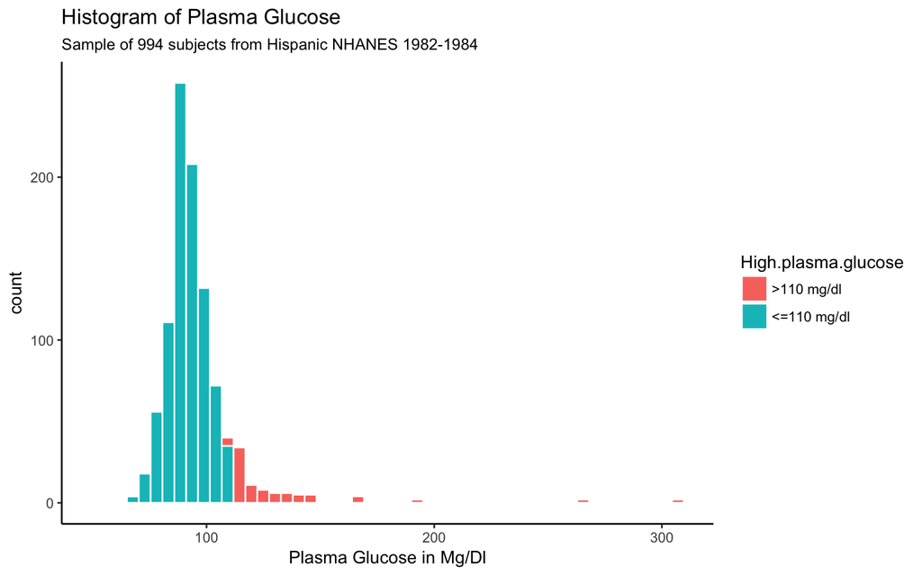

```r
theme_set(theme_classic())

# Histogram on a Continuous (Numeric) Variable
ggplot(data = HHANES_s, aes(x = plasma.glucose, fill = High.plasma.glucose)) +
    geom_histogram(color = "white", bins = 50) +
    labs(title = "Histogram of Plasma Glucose", subtitle = "Sample of 994 subjects from Hispanic NHANES 1982-1984", x = "Plasma Glucose in Mg/Dl")
```

### 10.1.2 Histogram by Sex

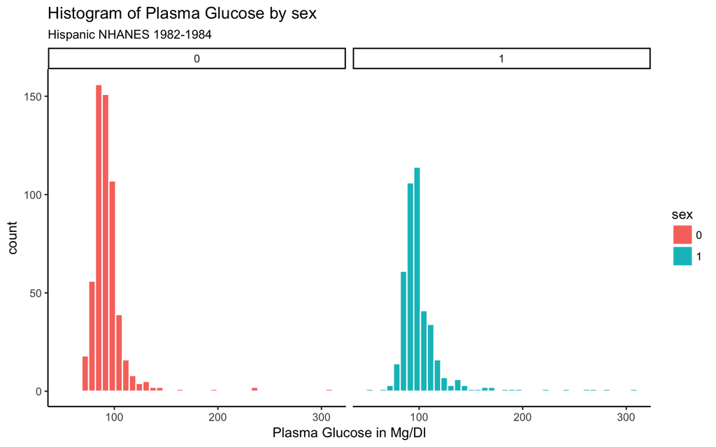

```r
theme_set(theme_classic())

# Histogram on a Continuous (Numeric) Variable
ggplot(data = HHANES_s, aes(x = plasma.glucose, fill = sex)) +
    geom_histogram(color = "white", bins = 40) +
    labs(title = "Histogram of Plasma Glucose by sex", subtitle = "Hispanic NHANES 1982-1984", x = "Plasma Glucose in Mg/Dl") +
    facet_wrap(~ sex)
```

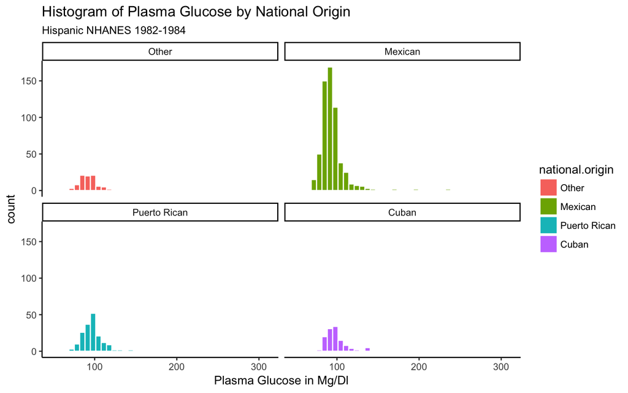

```r
theme_set(theme_classic())

# Histogram on a Continuous (Numeric) Variable
ggplot(data = HHANES_s, aes(x = plasma.glucose, fill = national.origin)) +
    geom_histogram(color = "white", bins = 40) +
    labs(title = "Histogram of Plasma Glucose by National Origin", subtitle = "Hispanic NHANES 1982-1984", x = "Plasma Glucose in Mg/Dl") +
    facet_wrap(~ national.origin)
```

### 10.1.3 Scatterplot Plasma Glucose By Age

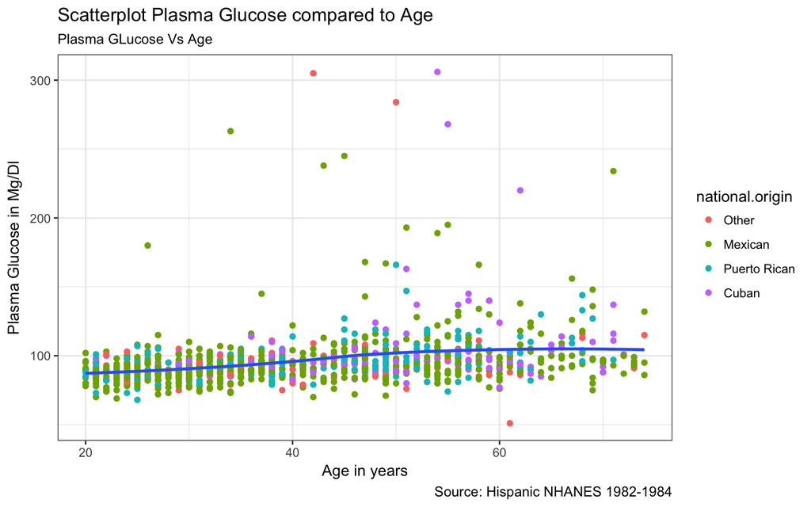

```r
options(scipen=999)  # turn-off scientific notation like 1e+48
theme_set(theme_bw())  # pre-set the bw theme.

# Scatterplot
pg_age <- ggplot(HHANES_s, aes(x=age, y=plasma.glucose)) +
  geom_point(aes(col=national.origin)) +
  geom_smooth(method="loess", se=F) +
  labs(subtitle="Plasma GLucose Vs Age",
       y="Plasma Glucose in Mg/Dl",
       x="Age in years",
       title="Scatterplot Plasma Glucose compared to Age", subtitle = "Sample of 994 subjects from Hispanic NHANES 1982-1984",
       caption = "Source: Hispanic NHANES 1982-1984")

plot(pg_age)
```

## 10.2 Visualizing Predictors

```r
p1 <- ggplot(HHANES_s, aes(x = plasma.glucose, fill=vegetables)) +
    geom_histogram(color = "white", bins = 50) +
    labs(title = "Histogram of Plasma Glucose", x = "Plasma Glucose in Mg/Dl")
    theme_bw()
```

[output not shown]

[output cut: 342 more lines]

[output not shown]

```r
p2 <-  ggplot(HHANES_s, aes(x = plasma.glucose, fill=fruit)) +
    geom_histogram(color = "white", bins = 50) +
    labs(title = "Histogram of Plasma Glucose", x = "Plasma Glucose in Mg/Dl")
    theme_bw()
```

[output not shown]

[output cut: 342 more lines]

[output not shown]

```r
p3 <-  ggplot(HHANES_s, aes(x = plasma.glucose, fill=sodas)) +
    geom_histogram(color = "white", bins = 50) +
    labs(title = "Histogram of Plasma Glucose", x = "Plasma Glucose in Mg/Dl")
    theme_bw()
```

[output not shown]

[output cut: 342 more lines]

[output not shown]

```r
p4 <-  ggplot(HHANES_s, aes(x = plasma.glucose, fill=cake.cookies)) +
    geom_histogram(color = "white", bins = 50) +
    labs(title = "Histogram of Plasma Glucose", x = "Plasma Glucose in Mg/Dl")
    theme_bw()
```

[output not shown]

[output cut: 342 more lines]

[output not shown]

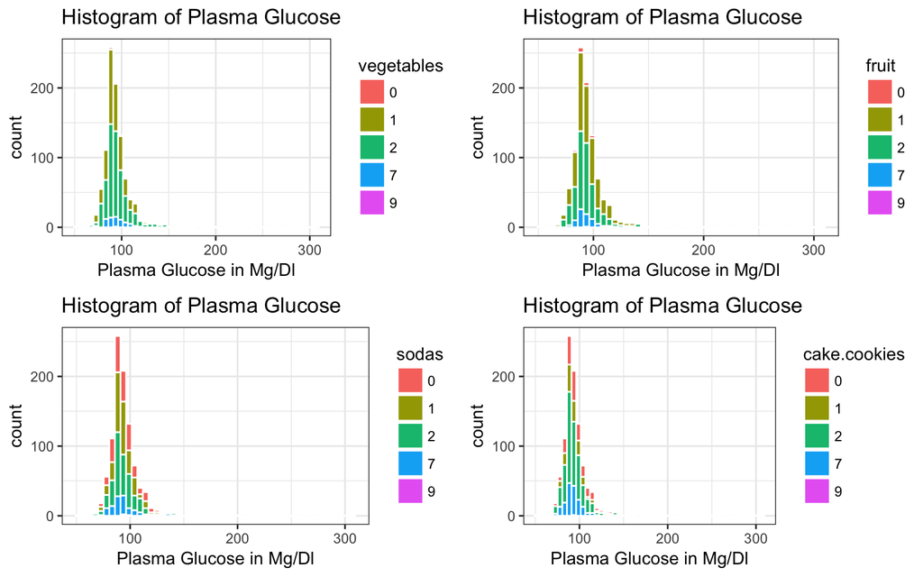

```r
gridExtra::grid.arrange(p1, p2, p3, p4, nrow = 2)
```